# 431 Class 07

Thomas E. Love, Ph.D.

2024-09-17

## Today’s Agenda

- Building an Uncertainty Interval when we have Two Independent Samples
  - Finishing the Example from Last Class
- One-Factor Analysis of Variance: Comparing More than Two Independent Samples
  - Using Regression to Develop an ANOVA model

## Load packages and set theme

```r
library(janitor)
library(knitr)
library(readxl)   # to read in an .xlsx file
library(car)
library(ggdist)   # for raincloud plots
library(MKinfer)
library(patchwork)
library(rstanarm)
library(easystats)
library(tidyverse)

theme_set(theme_bw())
knitr::opts_chunk$set(comment = NA)

source("c07/data/Love-431.R") # for the lovedist() function
```

## Returning to the DM-464 data

```r
dm7 <- read_csv("c07/data/dm464_class07.csv", show_col_types = FALSE) |>
  janitor::clean_names() |>
  mutate(across(where(is.character), as_factor)) |>
  mutate(statin_f = as_factor(statin),
         statin_f = fct_recode(statin_f,
                               "Statin" = "1", "No Statin" = "0")) |>
  mutate(id_code = as.character(id_code)) |>
  mutate(a1c_diff = a1c_end - a1c_base)

dim(dm7)
```

```
[1] 464  10
```

## A Strategy for Independent Samples

Suppose we want to estimate an uncertainty interval for the difference in means across two groups. To begin, plot the data from each sample.

- If the sample data in each group are well described as “Normal”, then use the OLS / pooled t procedure to obtain a confidence interval, or a Bayesian model to obtain a credible interval.
  - If the sample sizes are not the same, and the sample variances aren’t close to each other, consider using a Welch t procedure.
- If either sample’s data are “symmetric but with outliers”, then consider using the bootstrap to obtain a confidence interval, although an OLS or Bayesian result may also be reasonable.
- If either sample’s data are best described as “substantially skewed”, then consider whether you actually want to summarize with the difference in means, and consider whether a transformation might be helpful.

## Difference in A1c by Sex

```r
ggplot(dm7, aes(x = a1c_diff, y = sex)) +
  geom_violin() + geom_boxplot(aes(fill = sex), width = 0.3) +
  stat_summary(fun = mean, geom = "point", shape = 16, size = 3, col = "white") +
  labs(x = "Change in A1c", y = "Sex",
       title = "Difference in A1c (end - base) by Sex") +
  guides(fill = "none")
```

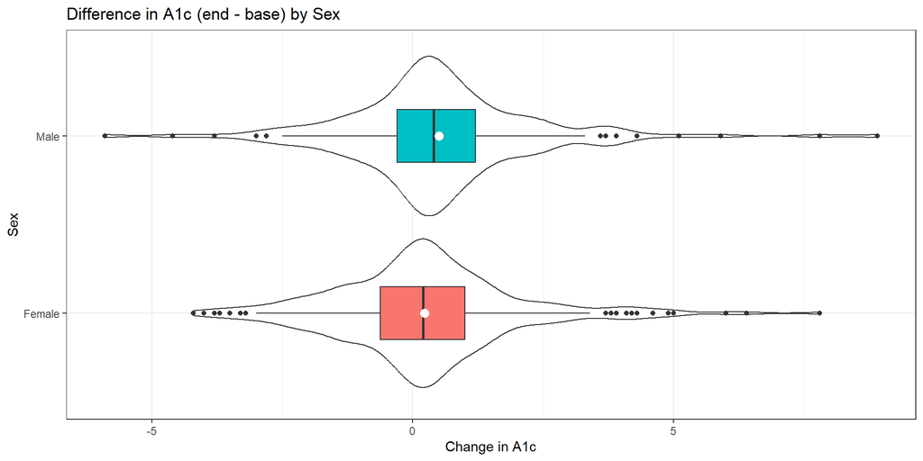

## Numerical Summary

```r
dm7 |> group_by(sex) |>
  reframe(lovedist(a1c_diff)) |>
  print_md(digits = 3)
```

| sex | n | miss | mean | sd | med | mad | min | q25 | q75 | max |
| --- | --- | --- | --- | --- | --- | --- | --- | --- | --- | --- |
| Female | 288 | 0 | 0.227 | 1.747 | 0.200 | 1.186 | -4.200 | -0.625 | 1.000 | 7.800 |
| Male | 176 | 0 | 0.503 | 1.838 | 0.400 | 1.186 | -5.900 | -0.300 | 1.200 | 8.900 |

- Observed difference in sample means is 0.503 - 0.227 = 0.276
- Do we have a balanced design?
- Do we feel comfortable pooling these standard deviations?
- Do we feel comfortable assuming Normality for each sex?

## Might a transformation help here?

Some of the changes in A1c are negative (minimum was -5.9)

```r
dm7 <- dm7 |> mutate(a1c_diff_p6 = a1c_diff + 6)
fit4 <- lm(a1c_diff_p6 ~ sex, data = dm7)
boxCox(fit4)
```

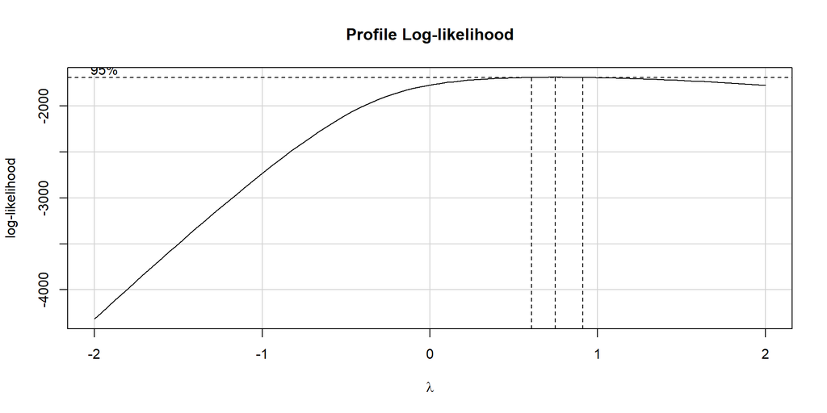

## Does using a square root help us here?

```r
p1 <- ggplot(dm7, aes(x = a1c_diff_p6, y = sex)) +
  geom_violin() + geom_boxplot(aes(fill = sex), width = 0.3) +
  stat_summary(fun = mean, geom = "point", shape = 16, size = 3, col = "white") +
  labs(x = "Change in A1c + 6", y = "Sex",
       title = "A1c difference (+ 6) by Sex") +
  guides(fill = "none")

p2 <- ggplot(dm7, aes(x = sqrt(a1c_diff_p6), y = sex)) +
  geom_violin() + geom_boxplot(aes(fill = sex), width = 0.3) +
  stat_summary(fun = mean, geom = "point", shape = 16, size = 3, col = "white") +
  labs(x = "Square Root of (Change in A1c + 6)", y = "Sex",
       title = "Square Root of (A1c difference + 6) by Sex") +
  guides(fill = "none")

p1 / p2
```

## Does using a square root help us here?

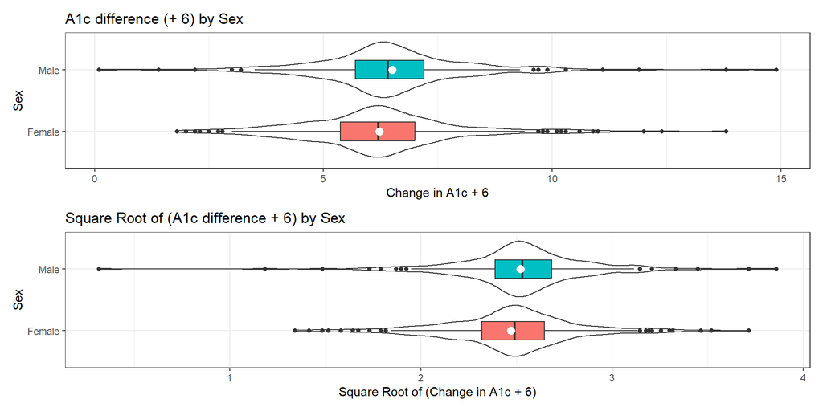

## Addressing outliers?

### OLS model

```r
fit5 <- lm(a1c_diff ~ sex, data = dm7)

model_parameters(fit5, ci = 0.90)
```

```
Parameter   | Coefficient |   SE |        90% CI | t(462) |     p
-----------------------------------------------------------------
(Intercept) |        0.23 | 0.11 | [ 0.05, 0.40] |   2.16 | 0.031
sex [Male]  |        0.28 | 0.17 | [ 0.00, 0.56] |   1.62 | 0.105
```

- Male subjects had A1c changes that were 0.28 larger than females, on average, with 90% uncertainty interval (0, 0.56) according to our OLS model (pooled t test.)

## Addressing outliers?

### Bayesian model

```r
set.seed(20240912)
fit6 <- stan_glm(a1c_diff ~ sex, data = dm7, refresh = 0)

model_parameters(fit6, ci = 0.90)
```

```
Parameter   | Median |        90% CI |     pd |  Rhat |     ESS |                 Prior
---------------------------------------------------------------------------------------
(Intercept) |   0.22 | [ 0.05, 0.39] | 98.42% | 1.000 | 3666.00 | Normal (0.33 +- 4.46)
sexMale     |   0.28 | [ 0.00, 0.57] | 94.80% | 1.000 | 3649.00 | Normal (0.00 +- 9.19)
```

- Male subjects had A1c changes that were 0.28 larger than females, on average, with 90% uncertainty interval (0, 0.57) according to our Bayesian model.

## Addressing outliers?

### Bootstrap with `boot.t.test` from `MKinfer`

```r
set.seed(20240912)
boot.t.test(a1c_diff ~ sex, data = dm7, conf.level = 0.90)
```

```
    Bootstrap Welch Two Sample t-test

data:  a1c_diff by sex
number of bootstrap samples:  9999
bootstrap p-value = 0.1096
bootstrap difference of means (SE) = -0.2787276 (0.1715815)
90 percent bootstrap percentile confidence interval:
 -0.566107955  0.002070707

Results without bootstrap:
t = -1.6028, df = 355.56, p-value = 0.1099
alternative hypothesis: true difference in means is not equal to 0
90 percent confidence interval:
 -0.561349458  0.008003498
sample estimates:
mean in group Female   mean in group Male
           0.2267361            0.5034091
```

## Comparing Our Results

These comparisons describe the Female - Male differences. The point estimate is -0.28.

| Method | 90% Uncertainty Interval |
| --- | --- |
| OLS / pooled t | (-0.56, 0.00) |
| Welch t | (-0.56, 0.01) |
| Bayesian model | (-0.57, 0.00) |
| Bootstrap<sup>1</sup> | (-0.57, 0.00) |

[^1]: without pooling the standard deviations

## 2 Independent Samples Strategy

Suppose we want to estimate an uncertainty interval for the difference in means across two groups. To begin, plot the data from each sample.

- If the sample data in each group are well described as “Normal”, then use the OLS / pooled t procedure to obtain a confidence interval, or a Bayesian model to obtain a credible interval.
  - If the sample sizes are not the same, and the sample variances aren’t close to each other, consider using a Welch t procedure.
- If either sample’s data are “symmetric but with outliers”, then consider using the bootstrap to obtain a confidence interval, although an OLS or Bayesian result may also be reasonable.
- If either sample’s data are best described as “substantially skewed”, then consider whether you actually want to summarize with the difference in means, and consider whether a transformation might be helpful.

## Paired Samples Strategy

Suppose we want to estimate an uncertainty interval for the mean of a set of paired differences.

- Calculate the paired differences, then plot them.
- If the sample data are well described as “Normal”, then use the OLS / paired t procedure to obtain a confidence interval, or a Bayesian model to obtain a credible interval.
- If the sample data are best described as “symmetric but with outliers”, then use the bootstrap to obtain a confidence interval, although an OLS or Bayesian result may be quite similar.
- If the sample data are best described as “substantially skewed”, then consider whether you actually want to summarize with the mean, and consider whether a transformation might be helpful.

# What if we have more than two independent samples?

## The `ohio_2020` data

`ohio_2020.xlsx` rows describe Ohio’s 88 counties:

- `FIPS` code (identifier for mapping), `state` and `county` name
- health outcomes (standardized: more positive means **better** outcomes, because we’ve taken the negative of the Z score CHR provides)
- health behavior ranking (1-88, we’ll divide into 4 groups)
- clinical care ranking (1-88, we’ll split into 3 groups)
- and some other variables

### Sources (these bullets are links)

- [County Health Rankings](https://www.countyhealthrankings.org/app/ohio/2020/downloads) (2020 Ohio Data)
- [Wikipedia for 2016 Election Results](https://en.wikipedia.org/wiki/2016_United_States_presidential_election_in_Ohio#By_county)

## Importing Data / Creating Factors

```r
ohio20 <- read_xlsx("c07/data/ohio_2020.xlsx") |>
  mutate(behavior = Hmisc::cut2(rk_behavior, g = 4),
         clin_care = Hmisc::cut2(rk_clin_care, g = 3)) |>
  mutate(behavior = fct_recode(behavior,
            "Best" = "[ 1,23)", "High" = "[23,45)",
            "Low" = "[45,67)", "Worst" = "[67,88]")) |>
  mutate(clin_care = fct_recode(clin_care,
            "Strong" = "[ 1,31)", "Middle" = "[31,60)",
            "Weak" = "[60,88]")) |>
  select(FIPS, state, county, outcomes, behavior, clin_care,
         everything())
```

## A Quick Look at the Data

```r
ohio20 |> filter(county == "Cuyahoga") |>
  select(FIPS, county, outcomes, behavior, clin_care)
```

```
# A tibble: 1 × 5
  FIPS  county   outcomes behavior clin_care
  <chr> <chr>       <dbl> <fct>    <fct>
1 39035 Cuyahoga   -0.807 Worst    Strong
```

```r
ggplot(ohio20, aes(x = "", y = outcomes)) + geom_violin(fill = "orange") +
  geom_boxplot(width = 0.4) +
  stat_summary(fun = mean, geom = "point", shape = 16, size = 3, col = "purple") +
  coord_flip() + labs(x = "")
```

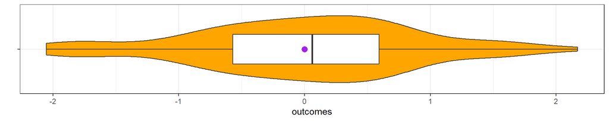

## Key Measure Details

- **outcomes** = quantity that describes the county’s premature death and quality of life results, weighted equally and standardized (z scores).
  - Higher (more positive) values indicate better outcomes in this county.

## Key Measure Details

- **behavior** = (Best/High/Low/Worst) reflecting adult smoking, obesity, food environment, inactivity, exercise, drinking, alcohol-related driving deaths, sexually transmitted infections and teen births.
  - Counties in the Best group had the best behavior results.

## Key Measure Details

- **clin_care** = (Strong/Middle/Weak) reflects rates of uninsured, care providers, preventable hospital stays, diabetes monitoring and mammography screening.
  - Strong means that clinical care is strong in this county.

### Today’s Question

1. How do average health outcomes vary across groups of counties defined by health behavior?

## $K (\geq 2)$ Samples: Comparing Means

1. What is the outcome under study?
2. What are the (in this case, $K \geq 2$) treatment/exposure groups?
3. Were the data in fact collected using independent samples?
4. Are the data random samples from the population(s) of interest? Or is there at least a reasonable argument for generalizing from the samples to the population(s)?
5. What is the uncertainty level we require?
6. Are we doing one-sided or two-sided testing? (usually 2-sided)
7. What does the distribution of each individual sample tell us about which inferential procedure to use?
8. Are there meaningful differences between population means?
9. Can we identify pairwise comparisons of means that show meaningful differences using an appropriate procedure that protects against Type I error expansion due to multiple comparisons? (to be discussed next time)

## Our Question

Do average health outcomes differ by health behavior?

```r
ggplot(ohio20, aes(x = behavior, y = outcomes,
                   fill = behavior)) +
  geom_violin(alpha = 0.25) +
  geom_boxplot(width = 0.25) +
  stat_summary(fun = mean, geom = "point", shape = 16, size = 3, col = "white") +
  guides(fill = "none") +
  scale_fill_brewer(palette = "Spectral", direction = -1) +
  labs(x = "Health Behavior Group",
       y = "Health Outcomes (higher = better health)",
       title = "Health Outcomes across Behavior Groups",
       subtitle = "Ohio's 88 counties, 2020 County Health Rankings",
       caption = "Source: https://www.countyhealthrankings.org/health-data/ohio/data-and-resources")
```

## Our Question

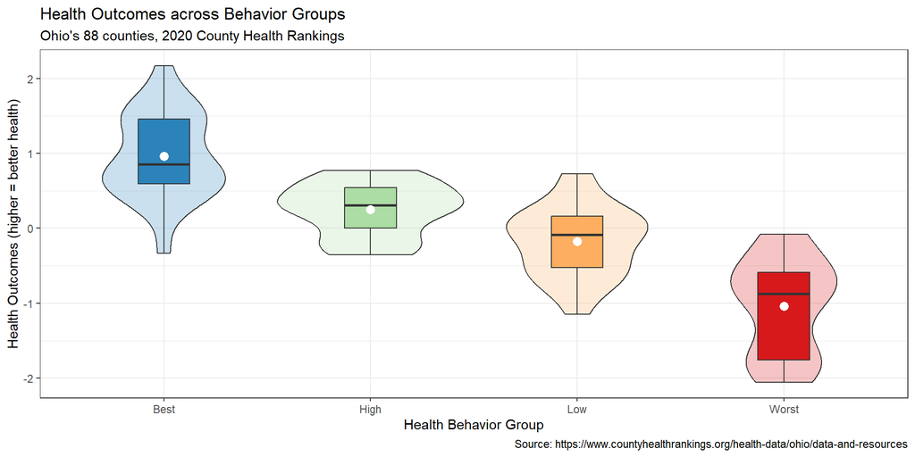

## Question 1 Raincloud Plots?

```r
ggplot(ohio20, aes(x = behavior, y = outcomes,
                   fill = behavior)) +
  ggdist::stat_halfeye(adjust = 0.5, width = 0.3, .width = c(0.5, 1)) +
  ggdist::stat_dots(side = "left", dotsize = 1, justification = 1.05, binwidth = 0.1) +
  guides(fill = "none") +
  scale_fill_brewer(palette = "Spectral", direction = -1) +
  labs(x = "Health Behavior Group",
       y = "Health Outcomes (higher = better health)",
       title = "Health Outcomes across Behavior Groups",
       subtitle = "Ohio's 88 counties, 2020 County Health Rankings",
       caption = "Source: https://www.countyhealthrankings.org/health-data/ohio/data-and-resources")
```

## Question 1 Raincloud Plots?

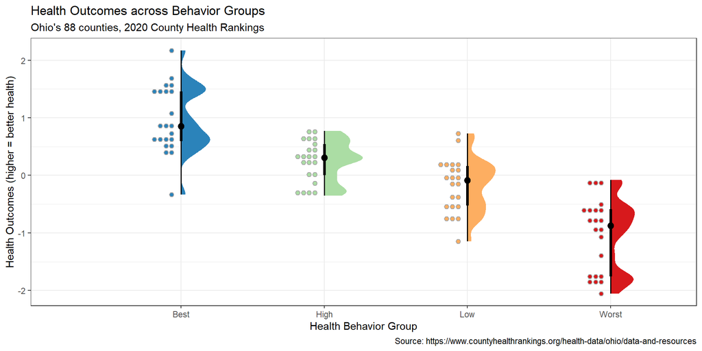

## Numerical Summaries by Group

How do average health outcomes vary across groups of counties defined by health behavior?

```r
ohio20 |>
  group_by(behavior) |>
  reframe(lovedist(outcomes)) |>
  kable(digits = 2)
```

| behavior | n | miss | mean | sd | med | mad | min | q25 | q75 | max |
| --- | --- | --- | --- | --- | --- | --- | --- | --- | --- | --- |
| Best | 22 | 0 | 0.96 | 0.57 | 0.86 | 0.60 | -0.33 | 0.60 | 1.46 | 2.17 |
| High | 22 | 0 | 0.25 | 0.35 | 0.30 | 0.41 | -0.35 | 0.00 | 0.55 | 0.77 |
| Low | 22 | 0 | -0.18 | 0.47 | -0.09 | 0.43 | -1.15 | -0.52 | 0.16 | 0.73 |
| Worst | 22 | 0 | -1.04 | 0.63 | -0.87 | 0.65 | -2.05 | -1.75 | -0.59 | -0.08 |

Note that there is no missing data here.

## Analysis of Variance: Question 1

Does the mean `outcomes` result differ meaningfully across the `behavior` groups?

$$H_0: \mu_{Best} = \mu_{High} = \mu_{Low} = \mu_{Worst} \mbox{ vs. } \\
H_A: \mbox{At least one } \mu \mbox{ is different.}$$

To test this set of hypotheses, we will build a linear model to predict each county’s outcome based on what behavior group the county is in.

## Building the Linear Model

Do we see meaningful differences in population means of `outcomes` across `behavior` groups?

```r
model_one <- lm(outcomes ~ behavior, data = ohio20)

model_parameters(model_one, ci = 0.90)
```

```
Parameter        | Coefficient |   SE |         90% CI |  t(84) |      p
------------------------------------------------------------------------
(Intercept)      |        0.96 | 0.11 | [ 0.78,  1.15] |   8.74 | < .001
behavior [High]  |       -0.71 | 0.16 | [-0.97, -0.45] |  -4.55 | < .001
behavior [Low]   |       -1.14 | 0.16 | [-1.40, -0.88] |  -7.32 | < .001
behavior [Worst] |       -2.01 | 0.16 | [-2.27, -1.75] | -12.85 | < .001
```

How do we interpret this result?

## Meaning of indicator variables?

```
outcomes = 0.96 - 0.71 behaviorHigh
           - 1.14 behaviorLow - 2.01 behaviorWorst
```

| group | `behaviorHigh` | `behaviorLow` | `behaviorWorst` |
| --- | --- | --- | --- |
| Best | 0 | 0 | 0 |
| High | 1 | 0 | 0 |
| Low | 0 | 1 | 0 |
| Worst | 0 | 0 | 1 |

- So what is the predicted `outcomes` score for a county in the High behavior group, according to this model?

## Interpreting the Indicator Variables

```
outcomes = 0.96 - 0.71 behaviorHigh
           - 1.14 behaviorLow - 2.01 behaviorWorst
```

What predictions does the model make? Do these make sense?

| group | `High` | `Low` | `Worst` | Prediction |
| --- | --- | --- | --- | --- |
| Best | 0 | 0 | 0 | 0.96 |
| High | 1 | 0 | 0 | 0.96 - 0.71 = 0.25 |
| Low | 0 | 1 | 0 | 0.96 - 1.14 = -0.18 |
| Worst | 0 | 0 | 1 | 0.96 - 2.01 = -1.05 |

## Interpreting the Indicator Variables

```
outcomes = 0.96 - 0.71 behaviorHigh
           - 1.14 behaviorLow - 2.01 behaviorWorst
```

```r
ohio20 |> group_by(behavior) |>
  summarise(n = n(), mean = round_half_up(mean(outcomes),2)) |>
  kable(digits = 2)
```

| behavior | n | mean |
| --- | --- | --- |
| Best | 22 | 0.96 |
| High | 22 | 0.25 |
| Low | 22 | -0.18 |
| Worst | 22 | -1.04 |

## ANOVA for Linear Model

Do we see meaningful differences in mean outcome across the behavior groups?

$$H_0: \mu_{Best} = \mu_{High} = \mu_{Low} = \mu_{Worst} \mbox{ vs. } \\
H_A: \mbox{At least one } \mu \mbox{ is different.}$$

```r
anova(model_one)
```

```
Analysis of Variance Table

Response: outcomes
          Df Sum Sq Mean Sq F value    Pr(>F)
behavior   3 46.421 15.4736  57.718 < 2.2e-16 ***
Residuals 84 22.519  0.2681
---
Signif. codes:  0 '***' 0.001 '**' 0.01 '*' 0.05 '.' 0.1 ' ' 1
```

## So, what’s in the ANOVA table? (df)

The ANOVA table reports here on a single **factor** (behavior group) with 4 levels, and on the residual variation in health **outcomes**.

```r
anova(model_one)[1:2]
```

```
          Df Sum Sq
behavior   3 46.421
Residuals 84 22.519
```

**Degrees of Freedom** (df) is an index of sample size…

- df for our factor (behavior) is one less than the number of categories. We have four behavior groups, so 3 degrees of freedom.
- Adding df(behavior) + df(Residuals) = 3 + 84 = 87 = df(Total), one less than the number of observations (counties) in Ohio.
- *n* observations and *g* groups yield $n - g$ residual df in a one-factor ANOVA table.

## ANOVA table: Sum of Squares

```r
anova(model_one)[1:3]
```

```
          Df Sum Sq Mean Sq
behavior   3 46.421 15.4736
Residuals 84 22.519  0.2681
```

**Sum of Squares** (`Sum Sq`, or SS) is an index of variation…

- SS(factor), here SS(`behavior`) measures the amount of variation accounted for by the `behavior` groups in our `model_one`.
- The total variation in `outcomes` to be explained by the model is SS(factor) + SS(Residuals) = SS(Total) in a one-factor ANOVA table.
- We describe the proportion of variation explained by a one-factor ANOVA model with $\eta^2$ (“eta-squared”: same as $R^2$ in regression)

$$\eta^2 = \frac{SS(\mbox{behavior})}{SS(\mbox{Total})} = \frac{46.421}{46.421+22.519} = \frac{46.421}{68.94} \approx 0.673$$

## ANOVA table: (Mean Square, F ratio)

```r
anova(model_one)[1:4]
```

```
          Df Sum Sq Mean Sq F value
behavior   3 46.421 15.4736  57.718
Residuals 84 22.519  0.2681
```

**Mean Square** (`Mean Sq`, or MS) = Sum of Squares / df

$$MS(\mbox{behavior}) = \frac{SS(\mbox{behavior})}{df(\mbox{behavior})} = \frac{46.421}{3} \approx 15.4736$$

- MS(Residuals) estimates the **residual variance**, the square of the residual standard deviation (residual standard error in earlier work).
- The ratio of MS values is the ANOVA **F value**.

$${\mbox{ANOVA }} F = \frac{MS(\mbox{behavior})}{MS(\mbox{Residuals})} = \frac{15.4736}{0.2681} \approx 57.718$$

## ANOVA Table p value

```r
anova(model_one)
```

```
Analysis of Variance Table

Response: outcomes
          Df Sum Sq Mean Sq F value    Pr(>F)
behavior   3 46.421 15.4736  57.718 < 2.2e-16 ***
Residuals 84 22.519  0.2681
---
Signif. codes:  0 '***' 0.001 '**' 0.01 '*' 0.05 '.' 0.1 ' ' 1
```

- The *p* value is derived from the ANOVA F statistic, as compared to the F distribution.
- Which F distribution is specified by the two degrees of freedom values…

```r
pf(57.718, df1 = 3, df2 = 84, lower.tail = FALSE)
```

```
[1] 2.377323e-20
```

## Alternative ANOVA display

```r
summary(aov(model_one))
```

```
            Df Sum Sq Mean Sq F value Pr(>F)
behavior     3  46.42  15.474   57.72 <2e-16 ***
Residuals   84  22.52   0.268
---
Signif. codes:  0 '***' 0.001 '**' 0.01 '*' 0.05 '.' 0.1 ' ' 1
```

```r
estimate_means(model_one, ci = 0.90)
```

```
Estimated Marginal Means

behavior |  Mean |   SE |         90% CI
----------------------------------------
Best     |  0.96 | 0.11 | [ 0.78,  1.15]
High     |  0.25 | 0.11 | [ 0.07,  0.44]
Low      | -0.18 | 0.11 | [-0.36,  0.01]
Worst    | -1.04 | 0.11 | [-1.22, -0.86]

Marginal means estimated at behavior
```

So, what might we conclude? Is this a surprise?

431 Class 07 | 2024-09-17 | https://thomaselove.github.io/431-2024/